# 01 - Exploratory data analysis

01_exploratory_analysis.qmd

# Overview

This document presents the exploratory data analysis that guided our investigation into the potential existence of trimorphism in *Longiperna concolor*.

# Load data

All data used in this study were collected during a mark-recapture survey conducted between October 2008 and April 2009 by Zatz et al. (2011).

The `MALES` dataset comprises individual-level information for nearly all *L. concolor* males marked during the study, including their unique ID and key body measurements: dorsal scute length (*DSmm*, in mm) and femur length of the fourth right leg (*F4mm*, in mm). The dataset also includes the morph classifications defined by Zatz et al. (2011).

*Note: Our dataset is missing one individual compared to Zatz et al. (2011). Additionally, we chose to ignore the individual 399M, since it appears to be a typo (i.e., it has the largest male dorsal scute length with a very small femur, which seems odd). Therefore, our dataset has 631 males instead of 633, as reported by Zatz et al. (2011).*

```
'data.frame':   631 obs. of  4 variables:
 $ ID       : Factor w/ 631 levels "100M","101M",..: 109 218 321 417 494 555 588 620 631 11 ...
 $ DSmm     : num  6.1 5.44 6.03 6.02 5.61 5.71 5.59 6 5.76 5.98 ...
 $ F4mm     : num  57 31.5 55.3 57.5 35.7 ...
 $ MorphZatz: Factor w/ 2 levels "Major","Minor": 1 1 1 1 1 1 1 1 1 1 ...
```

```
      DSmm            F4mm       MorphZatz
 Min.   :4.650   Min.   :14.44   Major:535
 1st Qu.:5.290   1st Qu.:32.12   Minor: 96
 Median :5.490   Median :39.35
 Mean   :5.489   Mean   :39.78
 3rd Qu.:5.690   3rd Qu.:49.32
 Max.   :6.200   Max.   :59.96
```

# Exploratory data analysis

The plot below illustrates the morph classification proposed by Zatz et al. (2011), in which major males exhibit longer fourth legs than minor males. In contrast, dorsal scute length shows substantial overlap between morphs, indicating that body size alone does not reliably distinguish them (Fig. 1).

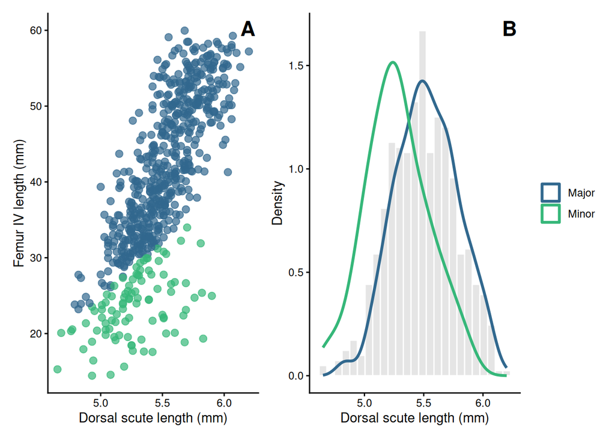

Figure 1: (A) Relationship between femur IV length and dorsal scute length for male morphs following the classification proposed by Zatz et al. (2011). In this species, dorsal scute length is a proxy for body size, whereas femur IV length reflects the size of the fourth pair of legs, which males use during territorial disputes. Major males display consistently longer femur IV lengths than minor males. (B) Distribution of dorsal scute length for all males. The histogram shows the overall unimodal size distribution in the population, while the density curves highlight the strong overlap between major and minor males.

Although males exhibit a unimodal distribution of dorsal scute length (Fig. 1b), the distribution of male femur IV length initially appears bimodal when examined without accounting for morph identity (Fig. 2a). However, once the data are partitioned by male morphs as defined by Zatz et al. (2011), it becomes evident that the distribution within the major morph is itself bimodal (Fig. 2b). This pattern prompted us to investigate the possibility of male trimorphism.

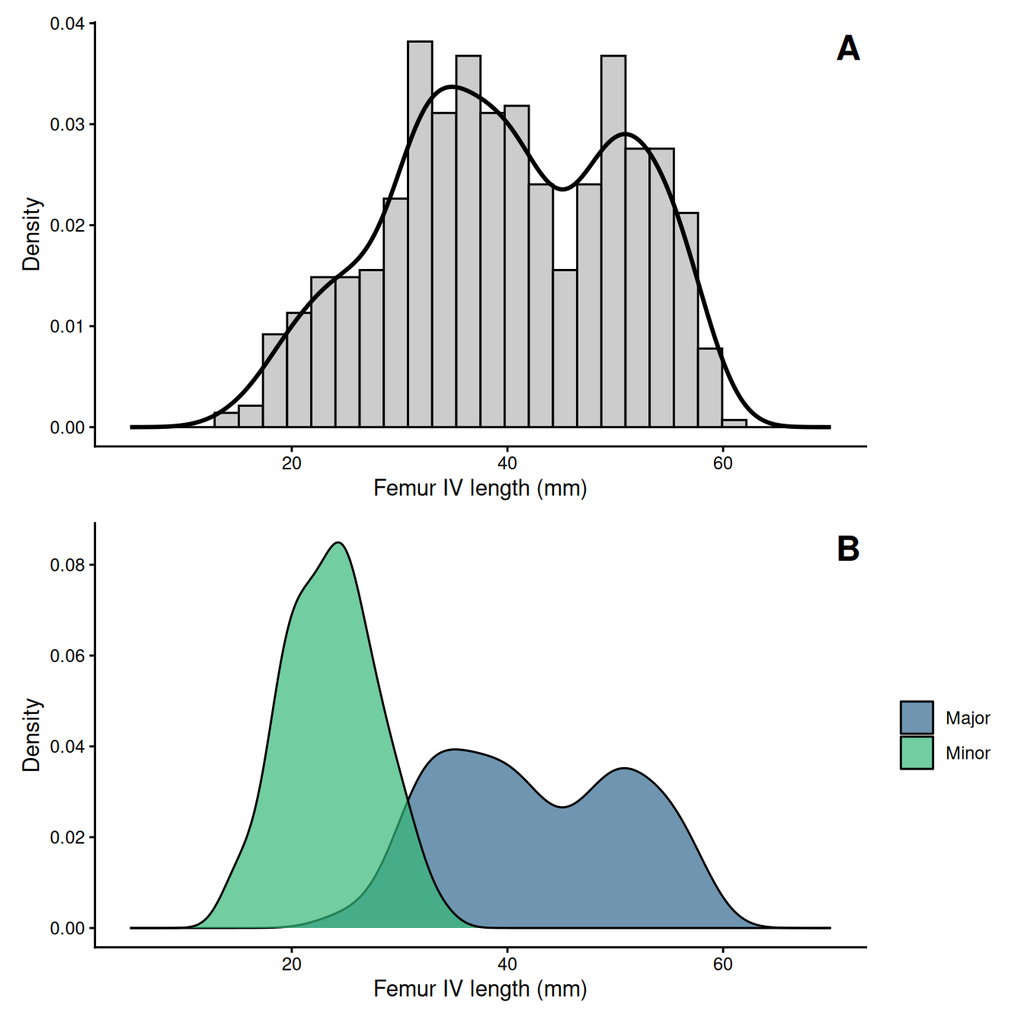

Figure 2: Distribution of femur IV length in Longiperna concolor males.(A) Histogram and density plot showing the overall male distribution, which appears bimodal when morph identity is ignored.(B) Density curves separated by morphs following the classification proposed by Zatz et al. (2011). The major morph displays a bimodal distribution, whereas the minor morph forms a single mode.

## References

Zatz, Camila, Rachel Werneck, Rogelio Macías-Ordóñez, and G. Machado. 2011. “Alternative Mating Tactics in Dimorphic Males of the Harvestman Longiperna Concolor (Arachnida: Opiliones).” *Behavioral Ecology and Sociobiology* 65 (May): 995–1005. https://doi.org/10.1007/s00265-010-1103-0.